# Pertemuan 1 MPDW - Prak

Fanka nareswari Salim

2026-08-21

# Packaage

```r
library("forecast")
```

```r
library("graphics")
library("TTR")
library("TSA")
```

# Data

```r
library(readxl)
data <- read_excel(file.choose())
head(data)
```

```
## # A tibble: 6 × 2
##   observation_date    CPIAUCSL_PC1
##   <dttm>                     <dbl>
## 1 1963-01-01 00:00:00        1.33
## 2 1963-02-01 00:00:00        1.23
## 3 1963-03-01 00:00:00        1.13
## 4 1963-04-01 00:00:00        0.894
## 5 1963-05-01 00:00:00        0.893
## 6 1963-06-01 00:00:00        1.32
```

# Normalisasikan

```r
str(data)
```

```
## tibble [180 × 2] (S3: tbl_df/tbl/data.frame)
##  $ observation_date: POSIXct[1:180], format: "1963-01-01" "1963-02-01" ...
##  $ CPIAUCSL_PC1    : num [1:180] 1.332 1.229 1.127 0.894 0.893 ...
```

```r
data$CPIAUCSL_PC1 <- as.numeric(
  gsub(",", "", data$CPIAUCSL_PC1)
)
str(data)
```

```
## tibble [180 × 2] (S3: tbl_df/tbl/data.frame)
##  $ observation_date: POSIXct[1:180], format: "1963-01-01" "1963-02-01" ...
##  $ CPIAUCSL_PC1    : num [1:180] 1.332 1.229 1.127 0.894 0.893 ...
```

# Mengubah data agar terbaca sebagai data deret waktu dengan fungsi ts()

```r
data.ts <- ts(data$CPIAUCSL_PC1 )
data.ts
```

```
## Time Series:
## Start = 1
## End = 180
## Frequency = 1
##   [1]  1.33156  1.22883  1.12695  0.89374  0.89286  1.32406  1.55526  1.55218
##   [9]  0.98619  1.21791  1.31666  1.64582  1.64258  1.41076  1.40937  1.54199
##  [17]  1.54048  1.30676  1.07527  0.97561  1.17188  1.20325  1.39701  1.19819
##  [25]  1.09890  1.19702  1.19586  1.38934  1.61394  1.93486  1.80529  1.61031
##  [33]  1.73745  1.70308  1.73021  1.92000  1.91816  2.55754  2.77866  2.86807
##  [41]  2.76366  2.43594  2.75491  3.48653  3.57369  3.79147  3.55906  3.35950
##  [49]  3.19950  2.86783  2.54817  2.54027  2.31839  2.84126  2.92758  2.60337
##  [57]  2.59542  2.58752  3.10219  3.28068  3.64742  3.63636  3.93939  3.92749
##  [65]  4.22961  4.20420  4.49102  4.47761  4.46429  4.74777  4.42478  4.70588
##  [73]  4.69208  4.67836  5.24781  5.52326  5.50725  5.47550  5.44413  5.42857
##  [81]  5.69801  5.66572  5.93220  5.89888  6.16246  6.42458  6.09418  6.06061
##  [89]  6.04396  6.01093  5.70652  5.69106  5.66038  5.63003  5.60000  5.57029
##  [97]  5.27704  4.72441  4.43864  4.15584  4.40415  4.38144  4.37018  4.35897
## [105]  4.08163  3.80711  3.53535  3.26633  3.25815  3.75940  3.50000  3.49127
## [113]  3.22581  2.96296  2.95567  2.94840  3.18627  3.17848  3.41463  3.40633
## [121]  3.64078  3.86473  4.83092  5.30120  5.52885  5.99520  5.74163  7.39857
## [129]  7.36342  8.05687  8.25472  8.94118  9.60187 10.00000 10.13825 10.06865
## [137] 10.70615 10.85973 11.53846 10.88889 11.94690 11.84211 12.20044 12.09503
## [145] 11.75214 11.20507 10.46025 10.18711  9.25926  9.18367  9.53347  8.61723
## [153]  7.90514  7.64706  7.37864  7.12909  6.69216  6.27376  6.06061  5.84906
## [161]  6.21469  5.98131  5.55556  5.71956  5.49451  5.46448  5.06329  5.03597
## [169]  5.19713  6.08229  6.42857  6.95187  6.73759  6.70194  6.66667  6.63176
## [177]  6.42361  6.39033  6.71256  6.67808
```

```r
summary(data.ts)
```

```
##    Min. 1st Qu.  Median    Mean 3rd Qu.    Max.
##  0.8929  2.7170  4.4317  4.7780  6.0853 12.2004
```

# Plot data deret waktu

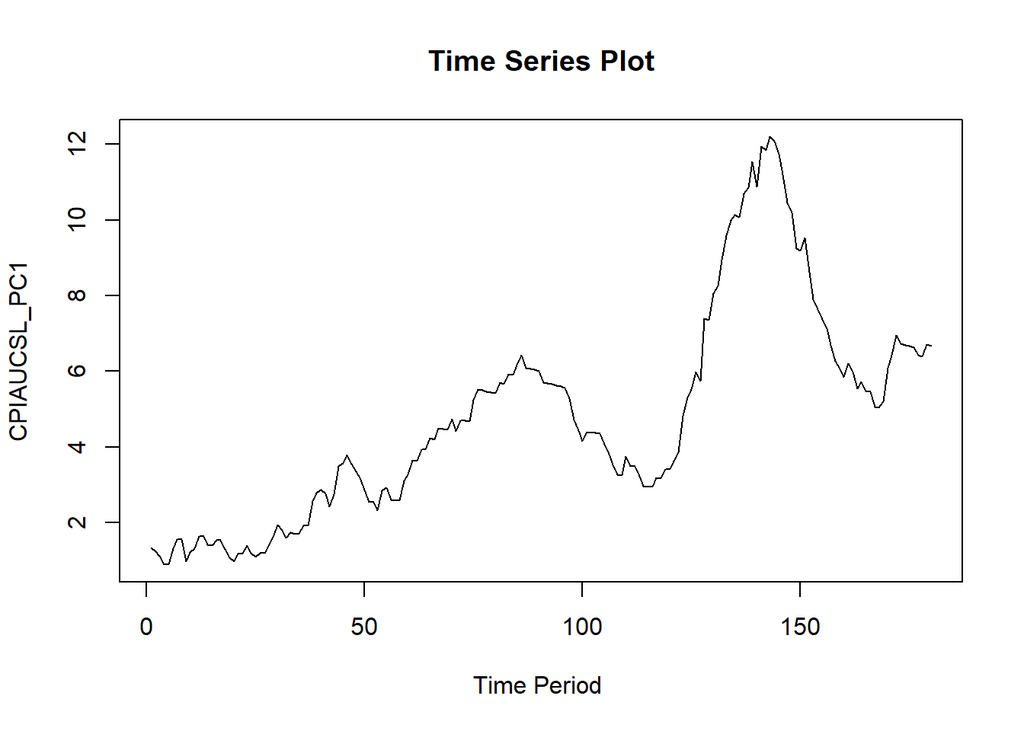

```r
ts.plot(data.ts, xlab="Time Period ", ylab="CPIAUCSL_PC1",
        main = "Time Series Plot")
```

# Single Moving Average & Double Moving Average

## Pembagian Data

Pembagian data latih dan data uji dilakukan dengan perbandingan 80% data latih dan 20% data uji.

```r
# hitung jumlah data
n <- nrow(data)

# tentukan batas 80%
n_train <- floor(0.8 * n)

# bagi data
training_ma <- data[1:n_train, ]
testing_ma  <- data[(n_train+1):n, ]

# ubah ke time series
train_ma.ts <- ts(training_ma$`CPIAUCSL_PC1`)
test_ma.ts  <- ts(testing_ma$`CPIAUCSL_PC1`)
```

```r
# cek jumlah data
cat("Jumlah data training :", nrow(training_ma), "\n")
```

```
## Jumlah data training : 144
```

```r
cat("Jumlah data testing  :", nrow(testing_ma), "\n")
```

```
## Jumlah data testing  : 36
```

```r
cat("Total data           :", nrow(training_ma) + nrow(testing_ma), "\n")
```

```
## Total data           : 180
```

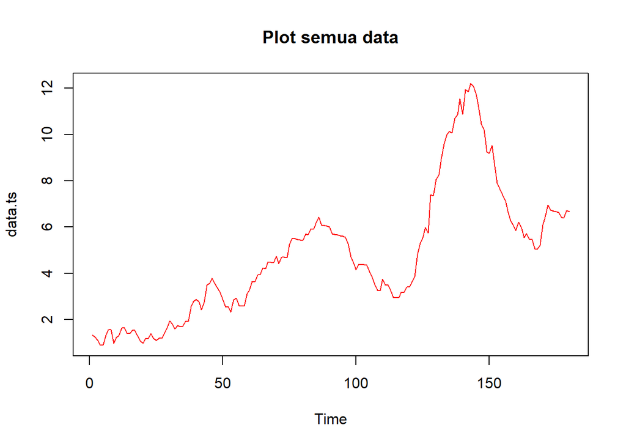

```r
#eksplorasi keseluruhan data
plot(data.ts, col="red",main="Plot semua data")
```

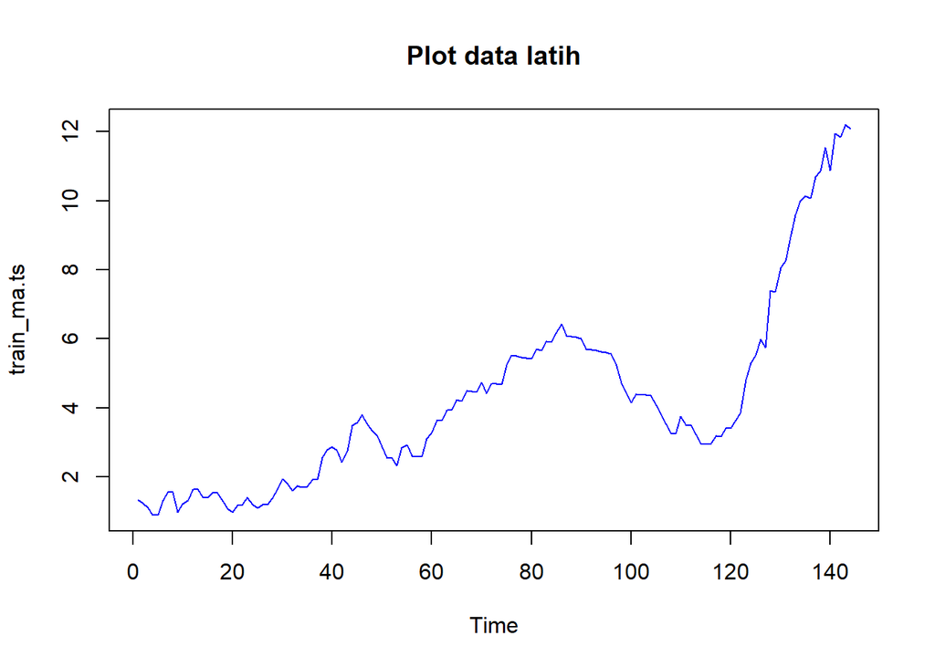

```r
#eksplorasi data latih
plot(train_ma.ts, col="blue",main="Plot data latih")
```

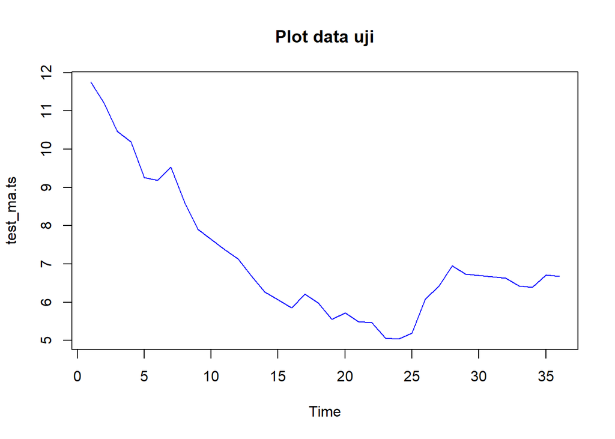

```r
#eksplorasi data uji
plot(test_ma.ts, col="blue",main="Plot data uji")
```

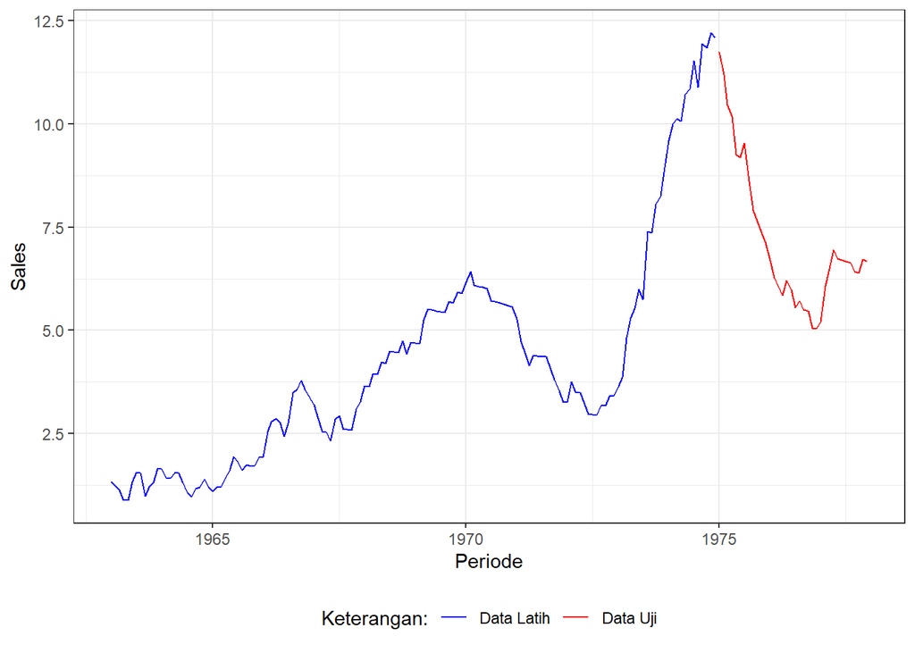

```r
library(ggplot2)

ggplot() +
  geom_line(
    data = training_ma,
    aes(x = observation_date, y = CPIAUCSL_PC1, col = "Data Latih")
  ) +
  geom_line(
    data = testing_ma,
    aes(x = observation_date, y = CPIAUCSL_PC1, col = "Data Uji")
  ) +
  labs(x = "Periode", y = "Sales", col = "Keterangan") +
  scale_colour_manual(
    name = "Keterangan:",
    breaks = c("Data Latih", "Data Uji"),
    values = c("blue", "red")
  ) +
  theme_bw() +
  theme(legend.position = "bottom")
```

## Single Moving Average (SMA)

```r
data.sma<-SMA(train_ma.ts, n=4)
data.sma
```

```
## Time Series:
## Start = 1
## End = 144
## Frequency = 1
##   [1]        NA        NA        NA  1.145270  1.035595  1.059402  1.166480
##   [8]  1.331090  1.354422  1.327885  1.268235  1.291645  1.455742  1.503955
##  [15]  1.527132  1.501175  1.475650  1.449650  1.366125  1.224530  1.132380
##  [22]  1.106502  1.186937  1.242582  1.224337  1.222780  1.172492  1.220280
##  [29]  1.349040  1.533500  1.685857  1.741100  1.771977  1.714032  1.695262
##  [36]  1.772685  1.817862  2.031477  2.293590  2.530607  2.741982  2.711583
##  [43]  2.705645  2.860260  3.062768  3.401650  3.602687  3.570930  3.477382
##  [50]  3.246472  2.993750  2.788942  2.568665  2.562022  2.656875  2.672650
##  [57]  2.741907  2.678472  2.722125  2.891452  3.154452  3.416662  3.625962
##  [64]  3.787665  3.933212  4.075172  4.213080  4.350610  4.409280  4.545172
##  [71]  4.528612  4.585680  4.642627  4.625275  4.831032  5.035377  5.239170
##  [78]  5.438455  5.487535  5.463862  5.511552  5.559107  5.681125  5.798702
##  [85]  5.914815  6.104530  6.145025  6.185457  6.155832  6.052420  5.955505
##  [92]  5.863117  5.767222  5.671997  5.645367  5.615175  5.519340  5.292935
##  [99]  5.002595  4.648982  4.430760  4.345017  4.327902  4.378685  4.298055
## [106]  4.154472  3.945765  3.672605  3.466735  3.454807  3.445970  3.502205
## [113]  3.494120  3.295010  3.158927  3.023210  3.013325  3.067205  3.181945
## [120]  3.296427  3.410055  3.581617  3.935690  4.409407  4.881425  5.414042
## [127]  5.641720  6.166063  6.624705  7.140122  7.768395  8.154047  8.713660
## [134]  9.199442  9.670325  9.952192 10.228262 10.443195 10.793247 10.998308
## [141] 11.308495 11.554090 11.719585 12.021120
```

Data pemulusan pada periode ke-t selanjutnya digunakan sebagai nilai peramalan pada periode ke t+1 sehingga hasil peramalan 1 periode kedepan adalah sebagai berikut.

```r
data.ramal<-c(NA,data.sma)
data.ramal #forecast 1 periode ke depan
```

```
##   [1]        NA        NA        NA        NA  1.145270  1.035595  1.059402
##   [8]  1.166480  1.331090  1.354422  1.327885  1.268235  1.291645  1.455742
##  [15]  1.503955  1.527132  1.501175  1.475650  1.449650  1.366125  1.224530
##  [22]  1.132380  1.106502  1.186937  1.242582  1.224337  1.222780  1.172492
##  [29]  1.220280  1.349040  1.533500  1.685857  1.741100  1.771977  1.714032
##  [36]  1.695262  1.772685  1.817862  2.031477  2.293590  2.530607  2.741982
##  [43]  2.711583  2.705645  2.860260  3.062768  3.401650  3.602687  3.570930
##  [50]  3.477382  3.246472  2.993750  2.788942  2.568665  2.562022  2.656875
##  [57]  2.672650  2.741907  2.678472  2.722125  2.891452  3.154452  3.416662
##  [64]  3.625962  3.787665  3.933212  4.075172  4.213080  4.350610  4.409280
##  [71]  4.545172  4.528612  4.585680  4.642627  4.625275  4.831032  5.035377
##  [78]  5.239170  5.438455  5.487535  5.463862  5.511552  5.559107  5.681125
##  [85]  5.798702  5.914815  6.104530  6.145025  6.185457  6.155832  6.052420
##  [92]  5.955505  5.863117  5.767222  5.671997  5.645367  5.615175  5.519340
##  [99]  5.292935  5.002595  4.648982  4.430760  4.345017  4.327902  4.378685
## [106]  4.298055  4.154472  3.945765  3.672605  3.466735  3.454807  3.445970
## [113]  3.502205  3.494120  3.295010  3.158927  3.023210  3.013325  3.067205
## [120]  3.181945  3.296427  3.410055  3.581617  3.935690  4.409407  4.881425
## [127]  5.414042  5.641720  6.166063  6.624705  7.140122  7.768395  8.154047
## [134]  8.713660  9.199442  9.670325  9.952192 10.228262 10.443195 10.793247
## [141] 10.998308 11.308495 11.554090 11.719585 12.021120
```

```r
data.gab<-cbind(
  aktual=c(data.ts),
  pemulusan=c(data.sma,rep(NA,100)),
  ramalan=c(data.ramal,rep(data.ramal[length(data.ramal)],99)))
data.gab
```

```
##          aktual pemulusan   ramalan
##   [1,]  1.33156        NA        NA
##   [2,]  1.22883        NA        NA
##   [3,]  1.12695        NA        NA
##   [4,]  0.89374  1.145270        NA
##   [5,]  0.89286  1.035595  1.145270
##   [6,]  1.32406  1.059402  1.035595
##   [7,]  1.55526  1.166480  1.059402
##   [8,]  1.55218  1.331090  1.166480
##   [9,]  0.98619  1.354422  1.331090
##  [10,]  1.21791  1.327885  1.354422
##  [11,]  1.31666  1.268235  1.327885
##  [12,]  1.64582  1.291645  1.268235
##  [13,]  1.64258  1.455742  1.291645
##  [14,]  1.41076  1.503955  1.455742
```

[output cut: 230 more lines]

Adapun plot data deret waktu dari hasil peramalan yang dilakukan adalah sebagai berikut:

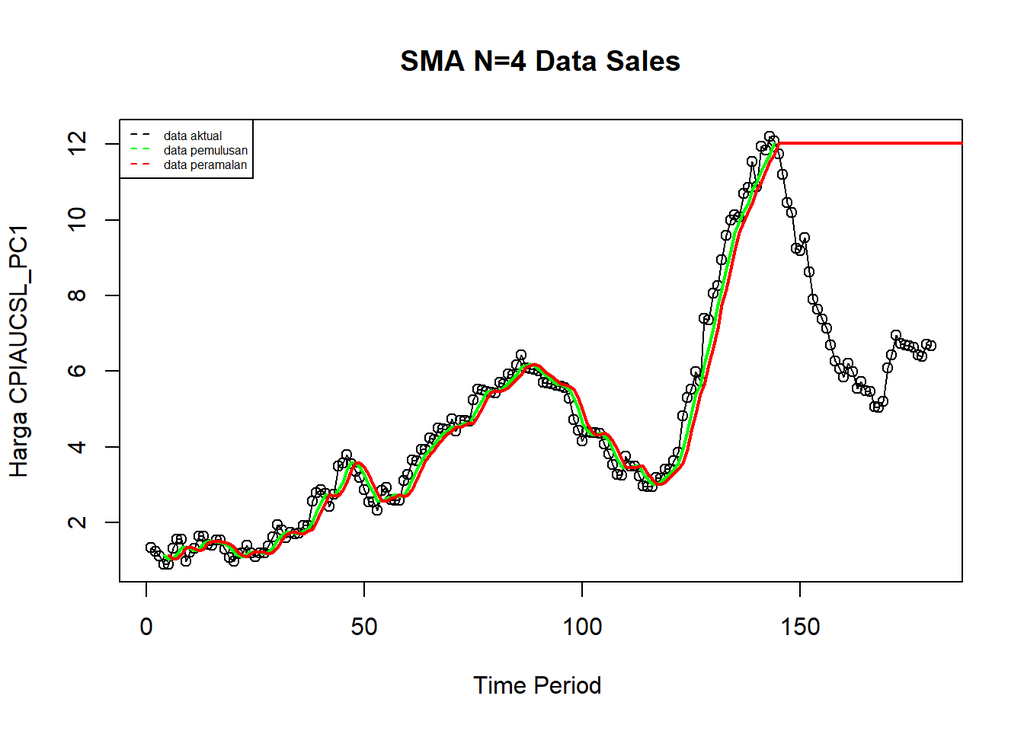

```r
ts.plot(data.ts, xlab="Time Period ", ylab="Harga CPIAUCSL_PC1", main= "SMA N=4 Data Sales")
points(data.ts)
lines(data.gab[,2],col="green",lwd=2)
lines(data.gab[,3],col="red",lwd=2)
legend("topleft",c("data aktual","data pemulusan","data peramalan"), lty=8, col=c("black","green","red"), cex=0.5)
```

```r
#Menghitung nilai keakuratan data latih
error_train.sma = train_ma.ts-data.ramal[1:length(train_ma.ts)]

SSE_train.sma = sum(error_train.sma[5:length(train_ma.ts)]^2)
MSE_train.sma = mean(error_train.sma[5:length(train_ma.ts)]^2)
MAPE_train.sma = mean(abs((error_train.sma[5:length(train_ma.ts)]/train_ma.ts[5:length(train_ma.ts)])*100))

akurasi_train.sma <- matrix(c(SSE_train.sma, MSE_train.sma, MAPE_train.sma))
row.names(akurasi_train.sma)<- c("SSE", "MSE", "MAPE")
colnames(akurasi_train.sma) <- c("Akurasi m = 4")
akurasi_train.sma
```

```
##      Akurasi m = 4
## SSE     40.2368771
## MSE      0.2874063
## MAPE    10.7854095
```

```r
#Menghitung nilai keakuratan data uji
error_test.sma = test_ma.ts-data.gab[97:120,3]
```

```r
SSE_test.sma = sum(error_test.sma^2)
MSE_test.sma = mean(error_test.sma^2)
MAPE_test.sma = mean(abs((error_test.sma/test_ma.ts*100)))

akurasi_test.sma <- matrix(c(SSE_test.sma, MSE_test.sma, MAPE_test.sma))
row.names(akurasi_test.sma)<- c("SSE", "MSE", "MAPE")
colnames(akurasi_test.sma) <- c("Akurasi m = 4")
akurasi_test.sma
```

[output not shown]

Nilai SSE dan MSE data uji jauh lebih besar dibandingkan data latih. Hal ini menunjukkan bahwa model memiliki kesalahan prediksi yang lebih besar ketika diterapkan pada data yang belum pernah dilihat sebelumnya. Dengan demikian, kemampuan generalisasi model masih kurang baik dan terdapat indikasi model kurang mampu memprediksi data uji secara akurat.

# Double Moving Average (DMA)

```r
dma <- SMA(data.sma, n = 4)
At <- 2*data.sma - dma
Bt <- 2/(4-1)*(data.sma - dma)
data.dma<- At+Bt
data.ramal2<- c(NA, data.dma)

t = 1:24
f = c()

for (i in t) {
  f[i] = At[length(At)] + Bt[length(Bt)]*(i)
}

data.gab2 <- cbind(aktual = c(data.ts),
                   pemulusan1 = c(data.sma,rep(NA,100)),
                   pemulusan2 = c(dma, rep(NA,100)),
                   At = c(At, rep(NA,100)),
                   Bt = c(Bt,rep(NA,100)),
                   ramalan = c(data.ramal2, f[-1]))
data.gab2
```

```
##          aktual pemulusan1 pemulusan2         At           Bt    ramalan
##   [1,]  1.33156         NA         NA         NA           NA         NA
##   [2,]  1.22883         NA         NA         NA           NA         NA
##   [3,]  1.12695         NA         NA         NA           NA         NA
##   [4,]  0.89374   1.145270         NA         NA           NA         NA
##   [5,]  0.89286   1.035595         NA         NA           NA         NA
##   [6,]  1.32406   1.059402         NA         NA           NA         NA
##   [7,]  1.55526   1.166480   1.101687  1.2312731  0.043195417         NA
##   [8,]  1.55218   1.331090   1.148142  1.5140381  0.121965417  1.2744685
##   [9,]  0.98619   1.354422   1.227849  1.4809962  0.084382500  1.6360035
##  [10,]  1.21791   1.327885   1.294969  1.3608006  0.021943750  1.5653787
##  [11,]  1.31666   1.268235   1.320408  1.2160619 -0.034782083  1.3827444
##  [12,]  1.64582   1.291645   1.310547  1.2727431 -0.012601250  1.1812798
##  [13,]  1.64258   1.455742   1.335877  1.5756081  0.079910417  1.2601419
##  [14,]  1.41076   1.503955   1.379894  1.6280156  0.082707083  1.6555185
```

[output cut: 230 more lines]

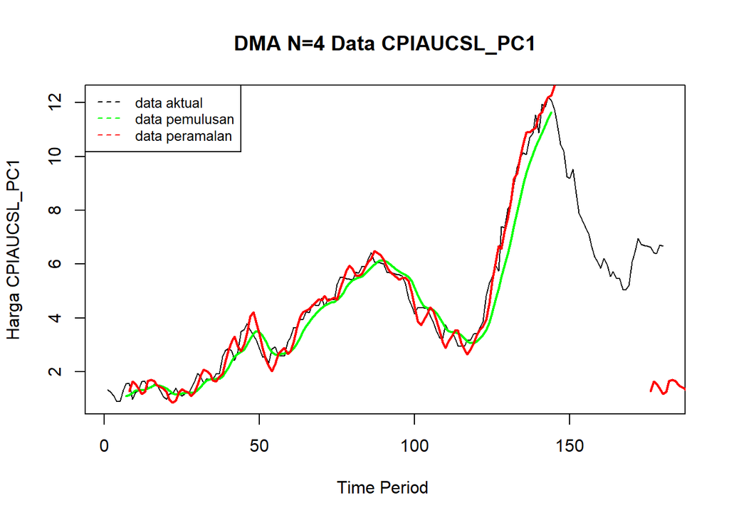

```r
ts.plot(data.ts, xlab="Time Period ", ylab="Harga CPIAUCSL_PC1", main= "DMA N=4 Data CPIAUCSL_PC1")
lines(data.gab2[,3],col="green",lwd=2)
lines(data.gab2[,6],col="red",lwd=2)
legend("topleft",c("data aktual","data pemulusan","data peramalan"), lty=8, col=c("black","green","red"), cex=0.8)
```

```r
#Menghitung nilai keakuratan data latih
error_train.dma = train_ma.ts-data.ramal2[1:length(train_ma.ts)]

SSE_train.dma = sum(error_train.dma[8:length(train_ma.ts)]^2)
MSE_train.dma = mean(error_train.dma[8:length(train_ma.ts)]^2)
MAPE_train.dma = mean(abs((error_train.dma[8:length(train_ma.ts)]/train_ma.ts[8:length(train_ma.ts)])*100))

akurasi_train.dma <- matrix(c(SSE_train.dma, MSE_train.dma, MAPE_train.dma))
row.names(akurasi_train.dma)<- c("SSE", "MSE", "MAPE")
colnames(akurasi_train.dma) <- c("Akurasi m = 4")
akurasi_train.dma
```

```
##      Akurasi m = 4
## SSE     19.7451518
## MSE      0.1441252
## MAPE    10.0164812
```

```r
#Menghitung nilai keakuratan data uji
error_test.dma = test_ma.ts-data.gab2[97:120,6]
```

```r
SSE_test.dma = sum(error_test.dma^2)
MSE_test.dma = mean(error_test.dma^2)
MAPE_test.dma = mean(abs((error_test.dma/test_ma.ts*100)))

akurasi_test.dma <- matrix(c(SSE_test.dma, MSE_test.dma, MAPE_test.dma))
row.names(akurasi_test.dma)<- c("SSE", "MSE", "MAPE")
colnames(akurasi_test.dma) <- c("Akurasi m = 4")
akurasi_test.dma
```

[output not shown]

Nilai SSE dan MSE pada data uji lebih besar dibandingkan data latih. Hal ini menunjukkan bahwa kesalahan prediksi model pada data uji lebih tinggi, sehingga kemampuan model dalam melakukan generalisasi terhadap data yang belum pernah diamati masih kurang baik.